# R Markdown

11 January 2019

## Overview

[figure not shown]

## Goals

1. To understand what R Markdown is (and isn't)
2. To be able to make your own output from R Markdown
3. To be able to apply R Markdown to your own work
   - Or know that it's not for you!

## Outline

### **Lecture** + Tutorial

1. What is R Markdown?
2. What can you use R Markdown for?
3. How does it work?

## Outline

### Lecture + **Tutorial**

Make your own R Markdown document

## What is R Markdown?

[figure not shown]

[figure not shown]

[figure not shown]

More specifically:

> Text + R output + graphics (+ R code) into a single document

## Possible uses

1. Quick report
   - R Notebooks
2. Full research paper
3. Presentation
4. PhD thesis…
5. Web page
6. eBook
7. Blog etc…

**Reproducible research**

## Markdown

[figure not shown]

"Markdown is a lightweight markup language with plain text formatting syntax." Source: Wikipedia

## Markdown - input

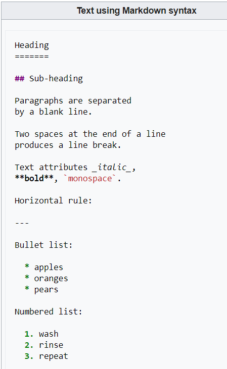

## Markdown - output

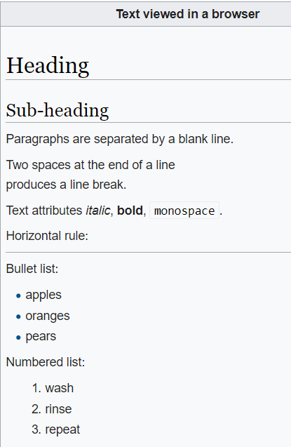

## Rmd to output

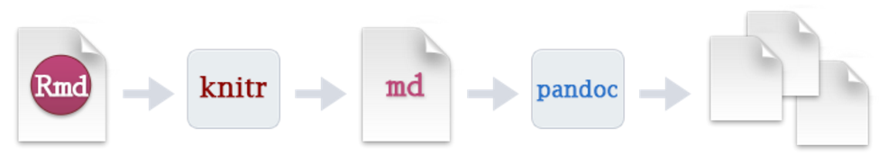

[figure not shown]

## Making a R Markdown file

[figure not shown]

[figure not shown]

[figure not shown]

## R Markdown anatomy

### YAML (aka *header*)

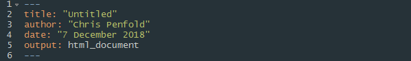

## R Markdown anatomy

### Markdown text

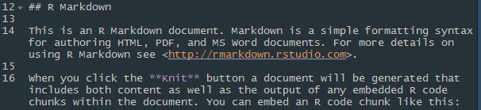

## R Markdown anatomy

### Code 'chunks'

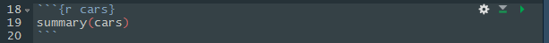

````
 ```{r cars}
summary(cars)
```
````

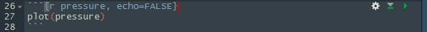

````
 ```{r pressure, echo=FALSE}
plot(pressure)
```
````

## R Markdown anatomy

### Setup code 'chunk'

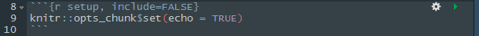

- Useful for setting up advanced options
- Also used for code not related to outputs, e.g.
- data cleaning
- deriving variables to be used later
- With `include=FALSE`, the code chunk will be evaluated (unless `eval=FALSE`), but the output will be completely suppressed.

## R Markdown anatomy

### Rendering the document

Then we 'knit' (render) the document

OR

- Press 'ctrl' + 'shift' + 'k'

## R Markdown anatomy

### *et voila:* rendered output

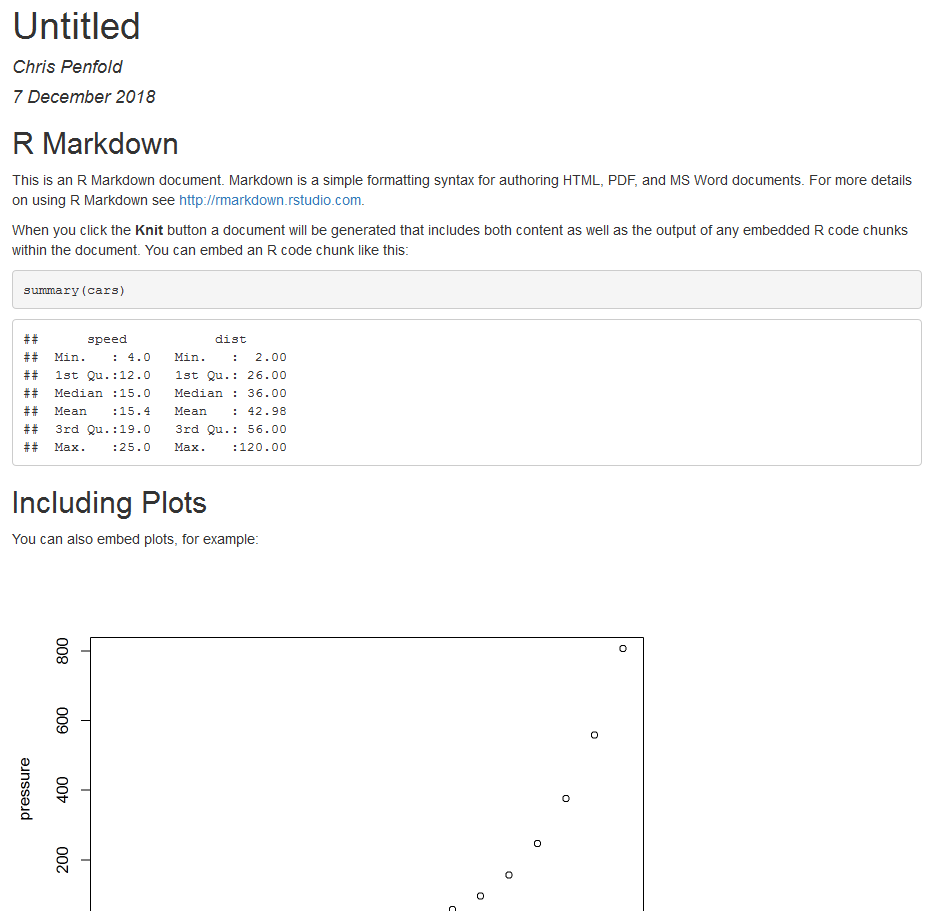

## Slide with Bullets

If I type:

`- Bullet 1`  
`- Bullet 2`  
`- Bullet 3`

I get:

- Bullet 1
- Bullet 2
- Bullet 3

## Slide with R Output

```r
summary(iris)
```

```
##   Sepal.Length    Sepal.Width     Petal.Length    Petal.Width
##  Min.   :4.300   Min.   :2.000   Min.   :1.000   Min.   :0.100
##  1st Qu.:5.100   1st Qu.:2.800   1st Qu.:1.600   1st Qu.:0.300
##  Median :5.800   Median :3.000   Median :4.350   Median :1.300
##  Mean   :5.843   Mean   :3.057   Mean   :3.758   Mean   :1.199
##  3rd Qu.:6.400   3rd Qu.:3.300   3rd Qu.:5.100   3rd Qu.:1.800
##  Max.   :7.900   Max.   :4.400   Max.   :6.900   Max.   :2.500
##        Species
##  setosa    :50
##  versicolor:50
##  virginica :50
##
##
##
```

## Slide with Plot

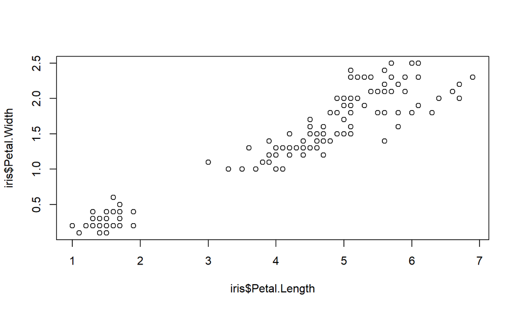

```r
plot(iris$Petal.Length, iris$Petal.Width)
```